# Kaggle_Project_1

Abhiram Mannam

2023-04-02

### KAGGLE PROJECT HOUSE PREDICTION

The main aim of this project is to predict the house prices in Ames, Iowa with the given variables (predictors) and predict the SalePrice (Target Variable). As every home buyers need to buy their dream house but estimating the cost of the house is difficult. So, this model will estimate the price of the house using the variables (predictors) from the house. The benchmark for this model is to have r-squared above .75 using only 5 predictors (variables)

### Import and explore the datasets.

Importing the train and test data using read_csv.

```r
train <- read_csv("train.csv") # Get the Train set data.
test <- read_csv("test.csv") # Get the Test set data.
```

Exploring the dataframe structure for the train set and it’s data types and names of every variable.

```r
str(train) # To get the structure of the train dataset.
```

```
## spc_tbl_ [1,460 × 81] (S3: spec_tbl_df/tbl_df/tbl/data.frame)
##  $ Id           : num [1:1460] 1 2 3 4 5 6 7 8 9 10 ...
##  $ MSSubClass   : num [1:1460] 60 20 60 70 60 50 20 60 50 190 ...
##  $ MSZoning     : chr [1:1460] "RL" "RL" "RL" "RL" ...
##  $ LotFrontage  : num [1:1460] 65 80 68 60 84 85 75 NA 51 50 ...
##  $ LotArea      : num [1:1460] 8450 9600 11250 9550 14260 ...
##  $ Street       : chr [1:1460] "Pave" "Pave" "Pave" "Pave" ...
##  $ Alley        : chr [1:1460] NA NA NA NA ...
##  $ LotShape     : chr [1:1460] "Reg" "Reg" "IR1" "IR1" ...
##  $ LandContour  : chr [1:1460] "Lvl" "Lvl" "Lvl" "Lvl" ...
##  $ Utilities    : chr [1:1460] "AllPub" "AllPub" "AllPub" "AllPub" ...
##  $ LotConfig    : chr [1:1460] "Inside" "FR2" "Inside" "Corner" ...
##  $ LandSlope    : chr [1:1460] "Gtl" "Gtl" "Gtl" "Gtl" ...
##  $ Neighborhood : chr [1:1460] "CollgCr" "Veenker" "CollgCr" "Crawfor" ...
##  $ Condition1   : chr [1:1460] "Norm" "Feedr" "Norm" "Norm" ...
##  $ Condition2   : chr [1:1460] "Norm" "Norm" "Norm" "Norm" ...
##  $ BldgType     : chr [1:1460] "1Fam" "1Fam" "1Fam" "1Fam" ...
##  $ HouseStyle   : chr [1:1460] "2Story" "1Story" "2Story" "2Story" ...
##  $ OverallQual  : num [1:1460] 7 6 7 7 8 5 8 7 7 5 ...
##  $ OverallCond  : num [1:1460] 5 8 5 5 5 5 5 6 5 6 ...
##  $ YearBuilt    : num [1:1460] 2003 1976 2001 1915 2000 ...
##  $ YearRemodAdd : num [1:1460] 2003 1976 2002 1970 2000 ...
##  $ RoofStyle    : chr [1:1460] "Gable" "Gable" "Gable" "Gable" ...
##  $ RoofMatl     : chr [1:1460] "CompShg" "CompShg" "CompShg" "CompShg" ...
##  $ Exterior1st  : chr [1:1460] "VinylSd" "MetalSd" "VinylSd" "Wd Sdng" ...
##  $ Exterior2nd  : chr [1:1460] "VinylSd" "MetalSd" "VinylSd" "Wd Shng" ...
##  $ MasVnrType   : chr [1:1460] "BrkFace" "None" "BrkFace" "None" ...
##  $ MasVnrArea   : num [1:1460] 196 0 162 0 350 0 186 240 0 0 ...
##  $ ExterQual    : chr [1:1460] "Gd" "TA" "Gd" "TA" ...
##  $ ExterCond    : chr [1:1460] "TA" "TA" "TA" "TA" ...
##  $ Foundation   : chr [1:1460] "PConc" "CBlock" "PConc" "BrkTil" ...
##  $ BsmtQual     : chr [1:1460] "Gd" "Gd" "Gd" "TA" ...
##  $ BsmtCond     : chr [1:1460] "TA" "TA" "TA" "Gd" ...
##  $ BsmtExposure : chr [1:1460] "No" "Gd" "Mn" "No" ...
##  $ BsmtFinType1 : chr [1:1460] "GLQ" "ALQ" "GLQ" "ALQ" ...
##  $ BsmtFinSF1   : num [1:1460] 706 978 486 216 655 ...
##  $ BsmtFinType2 : chr [1:1460] "Unf" "Unf" "Unf" "Unf" ...
##  $ BsmtFinSF2   : num [1:1460] 0 0 0 0 0 0 0 32 0 0 ...
##  $ BsmtUnfSF    : num [1:1460] 150 284 434 540 490 64 317 216 952 140 ...
##  $ TotalBsmtSF  : num [1:1460] 856 1262 920 756 1145 ...
```

[output cut: 112 more lines]

```
##   ..   EnclosedPorch = col_double(),
##   ..   `3SsnPorch` = col_double(),
##   ..   ScreenPorch = col_double(),
##   ..   PoolArea = col_double(),
##   ..   PoolQC = col_character(),
##   ..   Fence = col_character(),
##   ..   MiscFeature = col_character(),
##   ..   MiscVal = col_double(),
##   ..   MoSold = col_double(),
##   ..   YrSold = col_double(),
##   ..   SaleType = col_character(),
##   ..   SaleCondition = col_character(),
##   ..   SalePrice = col_double()
##   .. )
##  - attr(*, "problems")=<externalptr>
```

> Here we can see that the train dataset has 1460 rows with 80 columns (predictors) and one target variable (SalePrice). The dataset has num (numeric) and chr (character) datatypes. Some chr variables are factor variables which we need to convert it to factor before using them.

```r
str(test)
```

```
## spc_tbl_ [1,459 × 80] (S3: spec_tbl_df/tbl_df/tbl/data.frame)
##  $ Id           : num [1:1459] 1461 1462 1463 1464 1465 ...
##  $ MSSubClass   : num [1:1459] 20 20 60 60 120 60 20 60 20 20 ...
##  $ MSZoning     : chr [1:1459] "RH" "RL" "RL" "RL" ...
##  $ LotFrontage  : num [1:1459] 80 81 74 78 43 75 NA 63 85 70 ...
##  $ LotArea      : num [1:1459] 11622 14267 13830 9978 5005 ...
##  $ Street       : chr [1:1459] "Pave" "Pave" "Pave" "Pave" ...
##  $ Alley        : chr [1:1459] NA NA NA NA ...
##  $ LotShape     : chr [1:1459] "Reg" "IR1" "IR1" "IR1" ...
##  $ LandContour  : chr [1:1459] "Lvl" "Lvl" "Lvl" "Lvl" ...
##  $ Utilities    : chr [1:1459] "AllPub" "AllPub" "AllPub" "AllPub" ...
##  $ LotConfig    : chr [1:1459] "Inside" "Corner" "Inside" "Inside" ...
##  $ LandSlope    : chr [1:1459] "Gtl" "Gtl" "Gtl" "Gtl" ...
##  $ Neighborhood : chr [1:1459] "NAmes" "NAmes" "Gilbert" "Gilbert" ...
##  $ Condition1   : chr [1:1459] "Feedr" "Norm" "Norm" "Norm" ...
##  $ Condition2   : chr [1:1459] "Norm" "Norm" "Norm" "Norm" ...
##  $ BldgType     : chr [1:1459] "1Fam" "1Fam" "1Fam" "1Fam" ...
##  $ HouseStyle   : chr [1:1459] "1Story" "1Story" "2Story" "2Story" ...
##  $ OverallQual  : num [1:1459] 5 6 5 6 8 6 6 6 7 4 ...
##  $ OverallCond  : num [1:1459] 6 6 5 6 5 5 7 5 5 5 ...
##  $ YearBuilt    : num [1:1459] 1961 1958 1997 1998 1992 ...
##  $ YearRemodAdd : num [1:1459] 1961 1958 1998 1998 1992 ...
##  $ RoofStyle    : chr [1:1459] "Gable" "Hip" "Gable" "Gable" ...
##  $ RoofMatl     : chr [1:1459] "CompShg" "CompShg" "CompShg" "CompShg" ...
##  $ Exterior1st  : chr [1:1459] "VinylSd" "Wd Sdng" "VinylSd" "VinylSd" ...
##  $ Exterior2nd  : chr [1:1459] "VinylSd" "Wd Sdng" "VinylSd" "VinylSd" ...
##  $ MasVnrType   : chr [1:1459] "None" "BrkFace" "None" "BrkFace" ...
##  $ MasVnrArea   : num [1:1459] 0 108 0 20 0 0 0 0 0 0 ...
##  $ ExterQual    : chr [1:1459] "TA" "TA" "TA" "TA" ...
##  $ ExterCond    : chr [1:1459] "TA" "TA" "TA" "TA" ...
##  $ Foundation   : chr [1:1459] "CBlock" "CBlock" "PConc" "PConc" ...
##  $ BsmtQual     : chr [1:1459] "TA" "TA" "Gd" "TA" ...
##  $ BsmtCond     : chr [1:1459] "TA" "TA" "TA" "TA" ...
##  $ BsmtExposure : chr [1:1459] "No" "No" "No" "No" ...
##  $ BsmtFinType1 : chr [1:1459] "Rec" "ALQ" "GLQ" "GLQ" ...
##  $ BsmtFinSF1   : num [1:1459] 468 923 791 602 263 0 935 0 637 804 ...
##  $ BsmtFinType2 : chr [1:1459] "LwQ" "Unf" "Unf" "Unf" ...
##  $ BsmtFinSF2   : num [1:1459] 144 0 0 0 0 0 0 0 0 78 ...
##  $ BsmtUnfSF    : num [1:1459] 270 406 137 324 1017 ...
##  $ TotalBsmtSF  : num [1:1459] 882 1329 928 926 1280 ...
```

[output cut: 110 more lines]

```
##   ..   OpenPorchSF = col_double(),
##   ..   EnclosedPorch = col_double(),
##   ..   `3SsnPorch` = col_double(),
##   ..   ScreenPorch = col_double(),
##   ..   PoolArea = col_double(),
##   ..   PoolQC = col_character(),
##   ..   Fence = col_character(),
##   ..   MiscFeature = col_character(),
##   ..   MiscVal = col_double(),
##   ..   MoSold = col_double(),
##   ..   YrSold = col_double(),
##   ..   SaleType = col_character(),
##   ..   SaleCondition = col_character()
##   .. )
##  - attr(*, "problems")=<externalptr>
```

> Here we can see that the test dataset has 1459 rows with 80 columns (predictors). The dataset has num (numeric) and chr (character) datatypes. Some chr variables are factor variables which we need to convert it to factor before using them.

### Missing Values

To get the missing values in the dataset we can create the function name count_missings which has is.na() function and use it on the train dataset.

```r
count_missings <- function(x) sum(is.na(x))
train %>%
  summarize_all(count_missings)
```

```
## # A tibble: 1 × 81
##      Id MSSubClass MSZoning LotFr…¹ LotArea Street Alley LotSh…² LandC…³ Utili…⁴
##   <int>      <int>    <int>   <int>   <int>  <int> <int>   <int>   <int>   <int>
## 1     0          0        0     259       0      0  1369       0       0       0
## # … with 71 more variables: LotConfig <int>, LandSlope <int>,
## #   Neighborhood <int>, Condition1 <int>, Condition2 <int>, BldgType <int>,
## #   HouseStyle <int>, OverallQual <int>, OverallCond <int>, YearBuilt <int>,
## #   YearRemodAdd <int>, RoofStyle <int>, RoofMatl <int>, Exterior1st <int>,
## #   Exterior2nd <int>, MasVnrType <int>, MasVnrArea <int>, ExterQual <int>,
## #   ExterCond <int>, Foundation <int>, BsmtQual <int>, BsmtCond <int>,
## #   BsmtExposure <int>, BsmtFinType1 <int>, BsmtFinSF1 <int>, …
```

> Here we have some of the missing or NA values for some of the variables for example Alley has 1369 and PoolQC has 1453 missing values. We can impute the missing values for the required variables of this model.

To clean the missing variables we impute the numeric variables with the mean and chr variables with mode or none.

```r
train <- train %>%
  mutate(LotFrontage = replace_na (LotFrontage,mean(LotFrontage, na.rm = TRUE)),
         Alley = replace_na (Alley, replace = "None"),
         MasVnrType = replace_na (MasVnrType, replace = "None"),
         MasVnrArea = replace_na (MasVnrArea, replace = mean(MasVnrArea, na.rm = TRUE)),
         BsmtQual = replace_na (BsmtQual, replace = "None"),
         BsmtCond = replace_na (BsmtCond, replace = "None"),
         BsmtExposure = replace_na (BsmtExposure, replace = "None"),
         BsmtFinType1 = replace_na (BsmtFinType1, replace = "None"),
         BsmtFinType2 = replace_na (BsmtFinType2, replace = "None"),
         Electrical = replace_na(Electrical,Mode(Electrical, na.rm = TRUE)),
         FireplaceQu = replace_na (FireplaceQu, replace = "None"),
         GarageType = replace_na (GarageType, replace = "None"),
         GarageYrBlt = replace_na (GarageYrBlt, replace = median(GarageYrBlt, na.rm = TRUE)),
         GarageFinish = replace_na (GarageFinish, replace = "None"),
         GarageQual = replace_na (GarageQual, replace = "None"),
         GarageCond = replace_na (GarageCond, replace = "None"),
         PoolQC = replace_na (PoolQC, replace = "None"),
         Fence = replace_na(Fence, replace = "None"),
         MiscFeature = replace_na(MiscFeature , replace = "None")
         )
```

And we can see that we have 0 missing values.

```r
train %>%
  summarize_all(count_missings)
```

```
## # A tibble: 1 × 81
##      Id MSSubClass MSZoning LotFr…¹ LotArea Street Alley LotSh…² LandC…³ Utili…⁴
##   <int>      <int>    <int>   <int>   <int>  <int> <int>   <int>   <int>   <int>
## 1     0          0        0       0       0      0     0       0       0       0
## # … with 71 more variables: LotConfig <int>, LandSlope <int>,
## #   Neighborhood <int>, Condition1 <int>, Condition2 <int>, BldgType <int>,
## #   HouseStyle <int>, OverallQual <int>, OverallCond <int>, YearBuilt <int>,
## #   YearRemodAdd <int>, RoofStyle <int>, RoofMatl <int>, Exterior1st <int>,
## #   Exterior2nd <int>, MasVnrType <int>, MasVnrArea <int>, ExterQual <int>,
## #   ExterCond <int>, Foundation <int>, BsmtQual <int>, BsmtCond <int>,
## #   BsmtExposure <int>, BsmtFinType1 <int>, BsmtFinSF1 <int>, …
```

```r
sum(is.na(train))
```

```
## [1] 0
```

```r
test %>%
  summarize_all(count_missings)
```

```
## # A tibble: 1 × 80
##      Id MSSubClass MSZoning LotFr…¹ LotArea Street Alley LotSh…² LandC…³ Utili…⁴
##   <int>      <int>    <int>   <int>   <int>  <int> <int>   <int>   <int>   <int>
## 1     0          0        4     227       0      0  1352       0       0       2
## # … with 70 more variables: LotConfig <int>, LandSlope <int>,
## #   Neighborhood <int>, Condition1 <int>, Condition2 <int>, BldgType <int>,
## #   HouseStyle <int>, OverallQual <int>, OverallCond <int>, YearBuilt <int>,
## #   YearRemodAdd <int>, RoofStyle <int>, RoofMatl <int>, Exterior1st <int>,
## #   Exterior2nd <int>, MasVnrType <int>, MasVnrArea <int>, ExterQual <int>,
## #   ExterCond <int>, Foundation <int>, BsmtQual <int>, BsmtCond <int>,
## #   BsmtExposure <int>, BsmtFinType1 <int>, BsmtFinSF1 <int>, …
```

To clean the missing variables we impute the numeric variables with the mean and chr variables with mode or none.

```r
test <- test %>%
  mutate(MSZoning = replace_na(MSZoning,Mode(MSZoning, na.rm = TRUE)),
         LotFrontage = replace_na (LotFrontage,mean(LotFrontage, na.rm = TRUE)),
         Alley = replace_na (Alley, replace = "None"),
         Utilities = replace_na(Utilities,Mode(Utilities, na.rm = TRUE)),
         Exterior1st = replace_na(Exterior1st,Mode(Exterior1st, na.rm = TRUE)),
         Exterior2nd = replace_na(Exterior2nd,Mode(Exterior2nd, na.rm = TRUE)),
         MasVnrType = replace_na (MasVnrType, replace = "None"),
         MasVnrArea = replace_na (MasVnrArea, replace = mean(MasVnrArea, na.rm = TRUE)),
         BsmtQual = replace_na (BsmtQual, replace = "None"),
         BsmtCond = replace_na (BsmtCond, replace = "None"),
         BsmtExposure = replace_na (BsmtExposure, replace = "None"),
         BsmtFinType1 = replace_na (BsmtFinType1, replace = "None"),
         BsmtFinSF1 = replace_na (BsmtFinSF1,0),
         BsmtFinType2 = replace_na (BsmtFinType2, replace = "None"),
         BsmtFinSF2 = replace_na (BsmtFinSF2,mean(BsmtFinSF2, na.rm = TRUE)),
         BsmtUnfSF = replace_na (BsmtUnfSF,mean(BsmtUnfSF, na.rm = TRUE)),
         TotalBsmtSF = replace_na (TotalBsmtSF,mean(TotalBsmtSF, na.rm = TRUE)),
         BsmtFullBath = replace_na (BsmtFullBath,mean(BsmtFullBath, na.rm = TRUE)),
         BsmtHalfBath = replace_na (BsmtHalfBath,mean(BsmtHalfBath, na.rm = TRUE)),
         KitchenQual = replace_na(KitchenQual,Mode(KitchenQual, na.rm = TRUE)),
         Functional = replace_na(Functional,Mode(Functional, na.rm = TRUE)),
         FireplaceQu = replace_na (FireplaceQu, replace = "None"),
         GarageType = replace_na (GarageType, replace = "None"),
         GarageYrBlt = replace_na (GarageYrBlt, replace = median(GarageYrBlt, na.rm = TRUE)),
         GarageFinish = replace_na (GarageFinish, replace = "None"),
         GarageCars = replace_na(GarageCars,Mode(GarageCars, na.rm = TRUE)),
         GarageArea = replace_na (GarageArea,mean(GarageArea, na.rm = TRUE)),
         GarageQual = replace_na (GarageQual, replace = "None"),
         GarageCond = replace_na (GarageCond, replace = "None"),
         PoolQC = replace_na (PoolQC, replace = "None"),
         Fence = replace_na(Fence, replace = "None"),
         MiscFeature = replace_na(MiscFeature , replace = "None"),
         SaleType = replace_na(SaleType,Mode(SaleType, na.rm = TRUE))
         )
```

```r
test %>%
  summarize_all(count_missings)
```

```
## # A tibble: 1 × 80
##      Id MSSubClass MSZoning LotFr…¹ LotArea Street Alley LotSh…² LandC…³ Utili…⁴
##   <int>      <int>    <int>   <int>   <int>  <int> <int>   <int>   <int>   <int>
## 1     0          0        0       0       0      0     0       0       0       0
## # … with 70 more variables: LotConfig <int>, LandSlope <int>,
## #   Neighborhood <int>, Condition1 <int>, Condition2 <int>, BldgType <int>,
## #   HouseStyle <int>, OverallQual <int>, OverallCond <int>, YearBuilt <int>,
## #   YearRemodAdd <int>, RoofStyle <int>, RoofMatl <int>, Exterior1st <int>,
## #   Exterior2nd <int>, MasVnrType <int>, MasVnrArea <int>, ExterQual <int>,
## #   ExterCond <int>, Foundation <int>, BsmtQual <int>, BsmtCond <int>,
## #   BsmtExposure <int>, BsmtFinType1 <int>, BsmtFinSF1 <int>, …
```

```r
sum (is.na(test))
```

```
## [1] 0
```

We can see that we have 0 missing values.

### Choosing the variables

As per my experience Neighborhood (where the house resides in the city) is the important variable for every house price. It increases from one Neighborhood to other Neighborhood. Neighborhood is chr variable so we can’t use correlation to measure relation between those two variables. But, we can use linear regression model to model for the Neighborhhod and the target variable SalePrice.

```r
model1<- lm(SalePrice~Neighborhood,data=train)
summary(model1)
```

```
##
## Call:
## lm(formula = SalePrice ~ Neighborhood, data = train)
##
## Residuals:
##     Min      1Q  Median      3Q     Max
## -162271  -27552   -5324   19685  419705
##
## Coefficients:
##                     Estimate Std. Error t value Pr(>|t|)
## (Intercept)           194871      13097  14.879  < 2e-16 ***
## NeighborhoodBlueste   -57371      40367  -1.421 0.155463
## NeighborhoodBrDale    -90377      18809  -4.805 1.71e-06 ***
## NeighborhoodBrkSide   -70037      14893  -4.703 2.81e-06 ***
## NeighborhoodClearCr    17695      16603   1.066 0.286721
## NeighborhoodCollgCr     3095      13819   0.224 0.822820
## NeighborhoodCrawfor    15754      15123   1.042 0.297712
## NeighborhoodEdwards   -66651      14166  -4.705 2.78e-06 ***
## NeighborhoodGilbert    -2016      14437  -0.140 0.888944
## NeighborhoodIDOTRR    -94747      15822  -5.988 2.67e-09 ***
## NeighborhoodMeadowV   -96294      18522  -5.199 2.29e-07 ***
## NeighborhoodMitchel   -38601      15200  -2.540 0.011204 *
## NeighborhoodNAmes     -49024      13582  -3.609 0.000318 ***
## NeighborhoodNoRidge   140424      15577   9.015  < 2e-16 ***
## NeighborhoodNPkVill   -52176      22260  -2.344 0.019217 *
## NeighborhoodNridgHt   121400      14470   8.390  < 2e-16 ***
## NeighborhoodNWAmes     -5821      14542  -0.400 0.689011
## NeighborhoodOldTown   -66646      14047  -4.744 2.30e-06 ***
## NeighborhoodSawyer    -58078      14523  -3.999 6.69e-05 ***
## NeighborhoodSawyerW    -8315      14864  -0.559 0.575974
## NeighborhoodSomerst    30509      14333   2.129 0.033456 *
## NeighborhoodStoneBr   115628      16975   6.812 1.42e-11 ***
## NeighborhoodSWISU     -52280      16975  -3.080 0.002111 **
## NeighborhoodTimber     47377      15756   3.007 0.002686 **
## NeighborhoodVeenker    43902      20895   2.101 0.035810 *
## ---
## Signif. codes:  0 '***' 0.001 '**' 0.01 '*' 0.05 '.' 0.1 ' ' 1
##
## Residual standard error: 54000 on 1435 degrees of freedom
## Multiple R-squared:  0.5456, Adjusted R-squared:  0.538
## F-statistic: 71.78 on 24 and 1435 DF,  p-value: < 2.2e-16
```

We can see that R-squared value is 0.538. So, we can say that Neighborhood is the good predictor for the sales price.

We can see using the plot of between Neighborhood and Sales price.

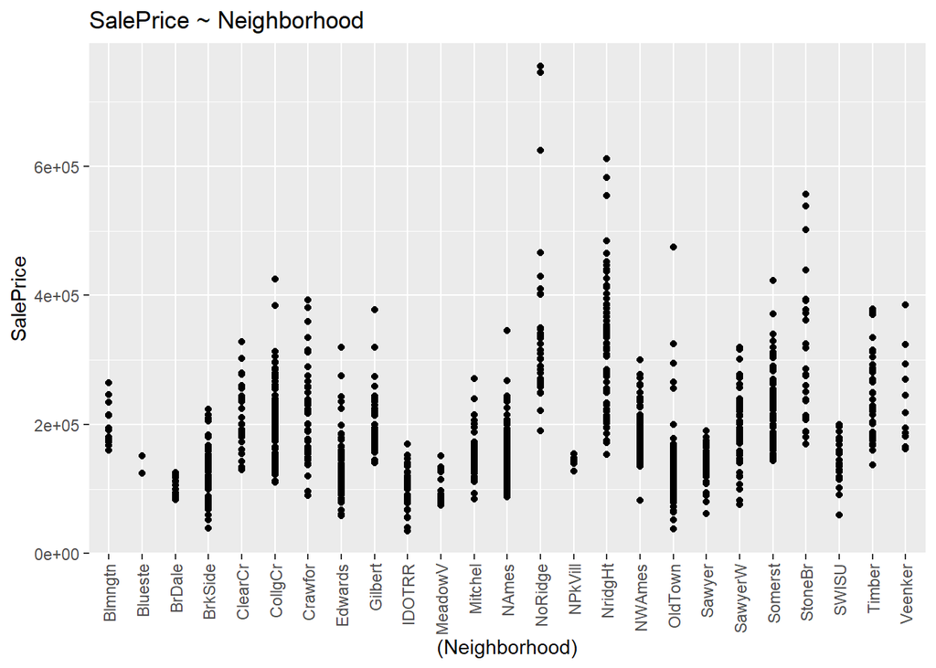

```r
ggplot(train, aes((Neighborhood), SalePrice)) +
  geom_point() +
  labs(title = "SalePrice ~ Neighborhood")+
  theme(axis.text.x = element_text(angle = 90, vjust = 0.5, hjust=1))
```

We can see that the plot that Neighborhood have an relationship with the sales price. That sales price depends on the Neighborhood.

Creating the summary table for the neighborhood using mean house price for every neighborhood.

```r
train %>%
  group_by(Neighborhood) %>%
  summarise(mean_average_sale_price = mean(SalePrice)) %>%
  arrange(desc(mean_average_sale_price)) %>%
  head(10)
```

```
## # A tibble: 10 × 2
##    Neighborhood mean_average_sale_price
##    <chr>                          <dbl>
##  1 NoRidge                      335295.
##  2 NridgHt                      316271.
##  3 StoneBr                      310499
##  4 Timber                       242247.
##  5 Veenker                      238773.
##  6 Somerst                      225380.
##  7 ClearCr                      212565.
##  8 Crawfor                      210625.
##  9 CollgCr                      197966.
## 10 Blmngtn                      194871.
```

Here from the summary table, we can see that NoRidge has his cost for houses, following by NridgHt and StoneBr.

Next is the OverallQual (Overall Material and Finish Quality) variable where every house is good quality or not. prices depend on the quality of the house. We can check the relation using correlation between OverallQual and SalesPrice.

```r
cor1<-cor(x=train$OverallQual, y=train$SalePrice)
cor1
```

```
## [1] 0.7909816
```

We can see that correlation is 0.79 which shows OverallQual has positive correlation with the Sales Price.

Let’s plot between OverallQual and SalesPrice

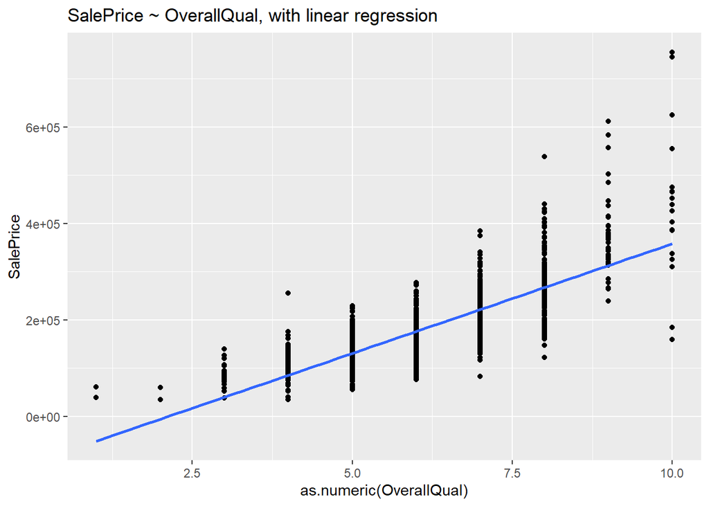

```r
ggplot(train, aes(as.numeric(OverallQual), SalePrice)) +
  geom_point() +
  geom_smooth(method = "lm", se = F) +
  labs(title = "SalePrice ~ OverallQual, with linear regression")
```

We can see that the plot has positive correlation of the OverallQual with the sales price.

Next is the GrLivArea (Above grade (ground) living area square feet) has positive effect on the price. High price has high GrLivArea. We can check this correlation.

```r
cor2<-cor(x=train$GrLivArea, y=train$SalePrice)
cor2
```

```
## [1] 0.7086245
```

We can see that correlation is 0.70 which shows GrLivArea has positive correlation with the Sales Price.

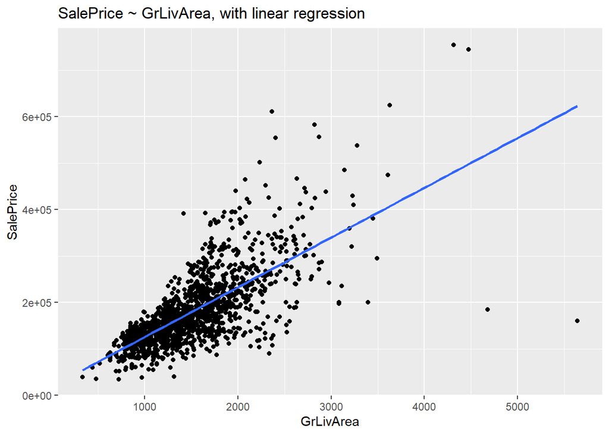

```r
ggplot(train, aes(GrLivArea, SalePrice)) +
  geom_point() +
  geom_smooth(method = "lm", se = F) +
  labs(title = "SalePrice ~ GrLivArea, with linear regression")
```

We can see from the plot that as sales Price increases with the increase in GrLivArea.

Next is the kitchenQual which shows what is the quality of the kitchen. It is the chr variable and it can be checked using the linear model whether it is a good variable to model or not.

```r
model2<- lm(SalePrice~KitchenQual,data=train)
summary(model2)
```

```
##
## Call:
## lm(formula = SalePrice ~ KitchenQual, data = train)
##
## Residuals:
##     Min      1Q  Median      3Q     Max
## -242555  -32566   -4963   25037  426445
##
## Coefficients:
##               Estimate Std. Error t value Pr(>|t|)
## (Intercept)     328555       5862   56.05   <2e-16 ***
## KitchenQualFa  -222990      11067  -20.15   <2e-16 ***
## KitchenQualGd  -116439       6343  -18.36   <2e-16 ***
## KitchenQualTA  -188592       6248  -30.18   <2e-16 ***
## ---
## Signif. codes:  0 '***' 0.001 '**' 0.01 '*' 0.05 '.' 0.1 ' ' 1
##
## Residual standard error: 58620 on 1456 degrees of freedom
## Multiple R-squared:  0.4566, Adjusted R-squared:  0.4555
## F-statistic: 407.8 on 3 and 1456 DF,  p-value: < 2.2e-16
```

Here we can see that R- squared value is 0455 which shows that the KitchenQual is statistically significant and important variable for the model of sales price.

```r
train %>%
  group_by(KitchenQual) %>%
  summarise(mean_average_sale_price = mean(SalePrice)) %>%
  arrange(desc(mean_average_sale_price)) %>%
  head()
```

```
## # A tibble: 4 × 2
##   KitchenQual mean_average_sale_price
##   <chr>                         <dbl>
## 1 Ex                          328555.
## 2 Gd                          212116.
## 3 TA                          139963.
## 4 Fa                          105565.
```

Here from the summary table, we can see that Ex(Excellent) has high price for houses followed by Gd (Good) and TA (Typical/Average) where Fa (Fair) type has low average sale_price.

Next is TotRmsAbvGrd which shows how many rooms above ground. It is a numeric variables and good relation with the price. It can be checked with the correlation.

```r
cor3<-cor(x=train$TotRmsAbvGrd, y=train$SalePrice)
cor3
```

```
## [1] 0.5337232
```

We can see that correlation is 0.53 which shows TotRmsAbvGrd has positive correlation with the Sales

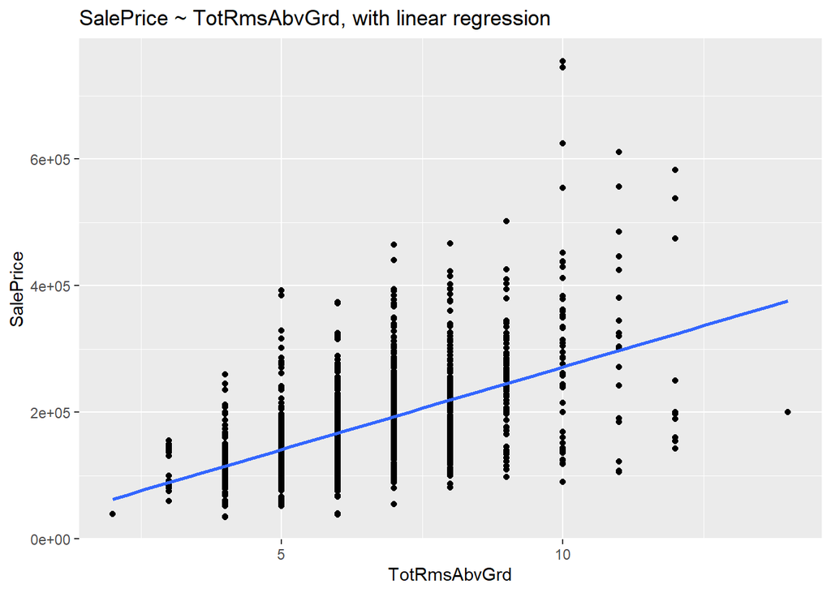

```r
ggplot(train, aes(TotRmsAbvGrd, SalePrice)) +
  geom_point() +
  geom_smooth(method = "lm", se = F) +
  labs(title = "SalePrice ~ TotRmsAbvGrd, with linear regression")
```

We can see that the TotRmsAbvGrd has positive relationship with the sales price.

So, from the above I have taken Neighborhood,TotRmsAbvGrd, OverallQual, KitchenQual, GrLivArea as the variables or predictors for the linear model.

### Cross-Validation

Cross-Validation is the method to divide the train data into two folds (mostly 70-30 split). One is train_fold and the other is validation_fold. We train the model on the train_fold and validate or test it on the validation_fold.

```r
set.seed(124)
# Randomly sample 70% of the rows
index <- sample(x = 1:nrow(train), size = nrow(train)*.7, replace = F)
head(index) # These are row numbers
```

```
## [1] 1345  167 1002 1435  261  728
```

```r
# Subset train using the index to create train_fold
train_fold <- train[index, ]
# Subset the remaining row to create validation fold.
validation_fold <- train[-index, ]
```

> Now we get train_fold with 70% data and validation_fold with 30% data. Fit model with the train_fold and test it on the validation_fold.

Let’s model the data using the variables or predictors described above.

Here, modeling the target variable saleprice using predictore OverallQual, GrLivArea, Neighborhood, KitchenQual and TotRmsAbvGrd.

```r
# Building the model.

model<- lm(SalePrice~as.numeric(OverallQual)+factor(Neighborhood)+factor(KitchenQual)+TotRmsAbvGrd+GrLivArea,data=train_fold)

summary(model) # Summary of the model.
```

```
##
## Call:
## lm(formula = SalePrice ~ as.numeric(OverallQual) + factor(Neighborhood) +
##     factor(KitchenQual) + TotRmsAbvGrd + GrLivArea, data = train_fold)
##
## Residuals:
##     Min      1Q  Median      3Q     Max
## -272329  -16509     360   14978  229276
##
## Coefficients:
##                               Estimate Std. Error t value Pr(>|t|)
## (Intercept)                  47708.373  15236.249   3.131  0.00179 **
## as.numeric(OverallQual)      16841.449   1369.572  12.297  < 2e-16 ***
## factor(Neighborhood)Blueste -20108.750  35839.801  -0.561  0.57487
## factor(Neighborhood)BrDale  -30868.776  13996.726  -2.205  0.02765 *
## factor(Neighborhood)BrkSide  -3317.446  11731.615  -0.283  0.77741
## factor(Neighborhood)ClearCr  30128.019  12595.519   2.392  0.01694 *
## factor(Neighborhood)CollgCr  18418.100  10496.815   1.755  0.07963 .
## factor(Neighborhood)Crawfor  27052.997  11596.246   2.333  0.01985 *
## factor(Neighborhood)Edwards  -9021.394  11232.945  -0.803  0.42210
## factor(Neighborhood)Gilbert  13563.800  10982.867   1.235  0.21712
## factor(Neighborhood)IDOTRR  -18807.612  12291.052  -1.530  0.12629
## factor(Neighborhood)MeadowV -14293.307  14199.395  -1.007  0.31437
## factor(Neighborhood)Mitchel  15211.583  11867.854   1.282  0.20023
## factor(Neighborhood)NAmes     5807.692  10611.779   0.547  0.58430
## factor(Neighborhood)NoRidge  78632.461  12378.786   6.352 3.23e-10 ***
## factor(Neighborhood)NPkVill  -3569.861  16508.023  -0.216  0.82884
## factor(Neighborhood)NridgHt  56882.784  11146.970   5.103 4.01e-07 ***
## factor(Neighborhood)NWAmes    5459.439  11362.813   0.480  0.63100
## factor(Neighborhood)OldTown -21788.623  10966.423  -1.987  0.04721 *
## factor(Neighborhood)Sawyer    7658.539  11332.679   0.676  0.49933
## factor(Neighborhood)SawyerW   9528.302  11498.046   0.829  0.40748
## factor(Neighborhood)Somerst  21236.657  10874.647   1.953  0.05112 .
## factor(Neighborhood)StoneBr  54251.006  13404.513   4.047 5.59e-05 ***
## factor(Neighborhood)SWISU   -19640.024  13062.584  -1.504  0.13302
## factor(Neighborhood)Timber   31337.214  12043.255   2.602  0.00941 **
## factor(Neighborhood)Veenker  55894.306  15206.359   3.676  0.00025 ***
## factor(KitchenQual)Fa       -72975.491   8988.052  -8.119 1.39e-15 ***
## factor(KitchenQual)Gd       -54848.738   5087.990 -10.780  < 2e-16 ***
## factor(KitchenQual)TA       -67094.856   5741.024 -11.687  < 2e-16 ***
## TotRmsAbvGrd                 -1543.712   1255.513  -1.230  0.21916
## GrLivArea                       57.091      4.618  12.362  < 2e-16 ***
## ---
## Signif. codes:  0 '***' 0.001 '**' 0.01 '*' 0.05 '.' 0.1 ' ' 1
##
## Residual standard error: 34300 on 990 degrees of freedom
## Multiple R-squared:  0.8116, Adjusted R-squared:  0.8059
## F-statistic: 142.1 on 30 and 990 DF,  p-value: < 2.2e-16
```

> Here we get Residual Standard Error as 34300 with R-squared as 0.8116. Which is greater than .75.

Here validating the model with the Validation fold and calculating the rmse and R2 for the validation fold using the model.

```r
predictions <- predict(model, newdata = validation_fold) # Predicting the model with new data.
# Calculating the rmse.
rmse <- function(observed, predicted) sqrt(mean((observed - predicted)^2))

#Calculating the R2.
R2 <- function(observed, predicted){
  TSS <- sum((observed - mean(observed))^2)
  RSS <- sum((observed - predicted)^2)
  1- RSS/TSS
}

rmse(validation_fold$SalePrice, predictions)
```

```
## [1] 37532.16
```

```r
R2(validation_fold$SalePrice, predictions)
```

```
## [1] 0.7951
```

> Here, the model has r-squared 0.7951 for the validation fold data with rmse is 37532.16

### Submission Model to the Kaggle

Here we create the submission model for the full train data.

```r
submission_model <- lm(SalePrice~as.numeric(OverallQual)+Neighborhood+KitchenQual+TotRmsAbvGrd+GrLivArea, data = train)
summary(submission_model)
```

```
##
## Call:
## lm(formula = SalePrice ~ as.numeric(OverallQual) + Neighborhood +
##     KitchenQual + TotRmsAbvGrd + GrLivArea, data = train)
##
## Residuals:
##     Min      1Q  Median      3Q     Max
## -335123  -16244      14   15133  242489
##
## Coefficients:
##                           Estimate Std. Error t value Pr(>|t|)
## (Intercept)              51515.527  13289.967   3.876 0.000111 ***
## as.numeric(OverallQual)  16540.820   1186.681  13.939  < 2e-16 ***
## NeighborhoodBlueste     -23898.221  26454.506  -0.903 0.366482
## NeighborhoodBrDale      -38526.696  12490.733  -3.084 0.002079 **
## NeighborhoodBrkSide     -11596.921  10096.687  -1.149 0.250919
## NeighborhoodClearCr      24062.906  11075.592   2.173 0.029974 *
## NeighborhoodCollgCr      11517.800   9041.755   1.274 0.202925
## NeighborhoodCrawfor      17993.946  10053.824   1.790 0.073704 .
## NeighborhoodEdwards     -18586.828   9617.514  -1.933 0.053483 .
## NeighborhoodGilbert       3842.892   9512.273   0.404 0.686278
## NeighborhoodIDOTRR      -27101.755  10707.571  -2.531 0.011478 *
## NeighborhoodMeadowV     -24025.161  12506.768  -1.921 0.054934 .
## NeighborhoodMitchel       5338.148  10165.541   0.525 0.599580
## NeighborhoodNAmes        -2724.207   9180.296  -0.297 0.766704
## NeighborhoodNoRidge      69306.005  10482.988   6.611 5.37e-11 ***
## NeighborhoodNPkVill     -11944.411  14681.742  -0.814 0.416035
## NeighborhoodNridgHt      55489.194   9642.892   5.754 1.06e-08 ***
## NeighborhoodNWAmes         601.126   9693.192   0.062 0.950559
## NeighborhoodOldTown     -31342.736   9492.931  -3.302 0.000985 ***
## NeighborhoodSawyer         181.422   9833.423   0.018 0.985283
## NeighborhoodSawyerW       2929.682   9782.965   0.299 0.764627
## NeighborhoodSomerst      16223.992   9363.681   1.733 0.083373 .
## NeighborhoodStoneBr      60057.437  11188.033   5.368 9.28e-08 ***
## NeighborhoodSWISU       -31562.936  11454.243  -2.756 0.005933 **
## NeighborhoodTimber       29767.672  10329.157   2.882 0.004012 **
## NeighborhoodVeenker      42290.986  13703.222   3.086 0.002066 **
## KitchenQualFa           -66714.443   7789.585  -8.565  < 2e-16 ***
## KitchenQualGd           -50324.873   4360.750 -11.540  < 2e-16 ***
## KitchenQualTA           -60281.138   4932.367 -12.222  < 2e-16 ***
## TotRmsAbvGrd              -918.226   1047.955  -0.876 0.381065
## GrLivArea                   54.556      3.797  14.368  < 2e-16 ***
## ---
## Signif. codes:  0 '***' 0.001 '**' 0.01 '*' 0.05 '.' 0.1 ' ' 1
##
## Residual standard error: 35190 on 1429 degrees of freedom
## Multiple R-squared:  0.8078, Adjusted R-squared:  0.8038
## F-statistic: 200.2 on 30 and 1429 DF,  p-value: < 2.2e-16
```

Here we predict the model for the test data.

```r
submission_predictions <- predict(submission_model, newdata = test)
```

Here we create new dataframe submission using test with id and submission_prediction columns.

```r
submission <- test %>%
  select(Id) %>%
  mutate(SalePrice = submission_predictions)
```

Exploring the first 6 rows of submission dataframe.

```r
head(submission)
```

```
## # A tibble: 6 × 2
##      Id SalePrice
##   <dbl>     <dbl>
## 1  1461   115505.
## 2  1462   164707.
## 3  1463   161144.
## 4  1464   185359.
## 5  1465   258815.
## 6  1466   178185.
```

Output the submission dataframe to file to PC and uploading it into kaggle.

```r
write.csv(submission,"submission.csv")
```

### Residual Plot

Plotting the residual plot from the submission model.

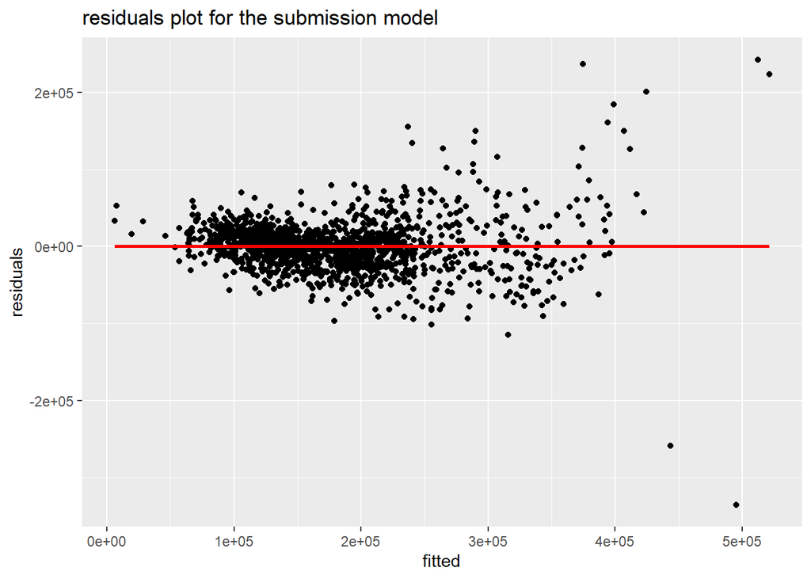

```r
train %>%
  mutate(fitted = fitted(submission_model),
         residuals = SalePrice - fitted) %>%
   ggplot(aes(fitted, residuals)) +
  geom_point() +
  geom_smooth(method = "lm", se = F, col = "red") +
  labs(title = "residuals plot for the submission model")
```

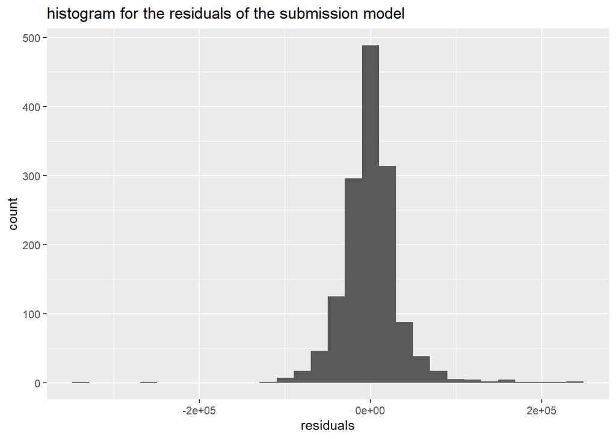

```r
train %>%
  mutate(fitted = fitted(submission_model),
         residuals = SalePrice - fitted) %>%
  ggplot(aes(x=residuals))+
  geom_histogram() +
  labs(title = "histogram for the residuals of the submission model")
```

> We can also see that the plot of histogram of the residuals shows the histogram follows normal distribution which proves that the model is good fit to the data.

> So, to conclude we have taken the five predictors to predict the target variable SalePrice using the Neighborhood, OverallQual, KitchenQual, TotRmsAbvGrd, GrLivArea. We cleaned the train and test data and divided into train_fold and validation_fold with 70-30 split. We get aroung R2 .8 and rmse as 34300 for train_fold and R2 of .79 with rmse of 37532 with validation which shows that my model passes the threshold R2 of.75 and submit the model output with test data to kaggle.

> Submitting the submission file to the Kaggle will get the score of 0.17833.